# WUM - Projekt 2 - kod źródłowy

Niewiasty WRS - Martyna Majchrzak, Agata Makarewicz, Renata Rólkiewicz

# 1. Wstęp

Poniższy projekt skupia się na klasteryzacji, czyli metodzie uczenia nienadzorowanego, której celem jest podział obserwacji na grupy obiektów podobnych do siebie zwanych klastrami.

**Użyte pakiety do projektu**

```python
import pandas as pd
import numpy as np
import sklearn
import statistics
import seaborn as sns
import matplotlib.pyplot as plt
import warnings
warnings.filterwarnings('ignore')
```

# 2. Zbiór danych

## Opis

Każdy wiersz w zbiorze opisuję sesję innego użytkownika podczas zakupów internetowych. Dane zostały zebrane na przestrzeni jednego roku, aby uniknąć wpływów czynników takich jak kampanie reklamowe, specjalne oferty, profil użytkownika, pora roku itd. Odwiedzone podczas dokonywania zakupu witryny zostały podzielone na 3 typy: Administrative - administracyjne, Informational - informacyjne oraz ProductRelated - związane z produktem.

Żródło danych: https://archive.ics.uci.edu/ml/datasets/Online+Shoppers+Purchasing+Intention+Dataset

**Zmienne związana z typami witryn:**

- Administrative - liczba odwiedzonych stron typu "Administrative" (zarządzanie kontem)
- Administrative_Duration - sumaryczny czas (w sekundach) spędzony na stronach typu "Administrative"
- Informational - liczba odwiedzonych stron typu "Informational" (informacje o stronie, kontakt, adres)
- Informational_Duration - sumaryczny czas (w sekundach) spędzony na stronach typu "Informational"
- ProductRelated - liczba odwiedzonych stron typu "ProductRelated" (strony związane z produktami)
- ProductRelated_Duration - sumaryczny czas (w sekundach) spędzony na stronach typu "ProductRelated"

**Zmienne związane z analizą Google Analytics:**

- BounceRates - procent odwiedzających stronę, którzy wychodzą z niej bez wykonania żadnego zapytania do serwera analitycznego poczas tej sesji
- ExitRates - procent wszystkich odwiedziń tej strony, które były ostanie w danej sesji
- PageValues - średnia wartość stron odwiedzonych przed dokonaniem transakcji

**Informacje o użytkowniku:**

- VisitorType - typ użytkownika (Returning_Visitor/New_Visitor/Other)
- OperatingSystems - system operacyjny użytkownika (zakodowane numerycznie liczbami od 1 do 8)
- Browser - przeglądarka użytkownika (zakodowane numerycznie liczbami od 1 do 13)
- Region - region, z którego pochodzi użytkownik (zakodowane numerycznie liczbami od 1 do 9)
- TrafficType - określa, w jaki sposób użytkownik dostał się na stronę, np. wpisując hasło w wyszukiwarkę/ klikając link (zakodowane numerycznie liczbami od 1 do 20)

**Informacje o transakcji:**

- SpecialDay - bliskość daty transakcji do szczególnych dni lub świąt (np. Dzień Matki) z uwzględnieniem np. czasu dostawy. Przykład: dla Walentynek - wartości niezerowe są od 2 do 12 lutego, a najwyższą wartość (równą 1) przyjmuje 8 lutego
- Month - miesiąc
- Weekend - informacja czy zakup został dokonany w trakcie weekendu (False/True)
- Revenue - informacja czy doszło do transakcji (False/True)

Opisy miar Google Analytics: https://support.google.com/analytics/answer/2525491?hl=en&ref_topic=6156780

```python
data = pd.read_csv('online_shoppers_intention.csv')
data.head(10)
```

|  | Administrative | Administrative_Duration | Informational | Informational_Duration | ProductRelated | ProductRelated_Duration | BounceRates | ExitRates | PageValues | SpecialDay | Month | OperatingSystems | Browser | Region | TrafficType | VisitorType | Weekend | Revenue |
| --- | --- | --- | --- | --- | --- | --- | --- | --- | --- | --- | --- | --- | --- | --- | --- | --- | --- | --- |
| 0 | 0 | 0.0 | 0 | 0.0 | 1 | 0.000000 | 0.200000 | 0.200000 | 0.0 | 0.0 | Feb | 1 | 1 | 1 | 1 | Returning_Visitor | False | False |
| 1 | 0 | 0.0 | 0 | 0.0 | 2 | 64.000000 | 0.000000 | 0.100000 | 0.0 | 0.0 | Feb | 2 | 2 | 1 | 2 | Returning_Visitor | False | False |
| 2 | 0 | 0.0 | 0 | 0.0 | 1 | 0.000000 | 0.200000 | 0.200000 | 0.0 | 0.0 | Feb | 4 | 1 | 9 | 3 | Returning_Visitor | False | False |
| 3 | 0 | 0.0 | 0 | 0.0 | 2 | 2.666667 | 0.050000 | 0.140000 | 0.0 | 0.0 | Feb | 3 | 2 | 2 | 4 | Returning_Visitor | False | False |
| 4 | 0 | 0.0 | 0 | 0.0 | 10 | 627.500000 | 0.020000 | 0.050000 | 0.0 | 0.0 | Feb | 3 | 3 | 1 | 4 | Returning_Visitor | True | False |
| 5 | 0 | 0.0 | 0 | 0.0 | 19 | 154.216667 | 0.015789 | 0.024561 | 0.0 | 0.0 | Feb | 2 | 2 | 1 | 3 | Returning_Visitor | False | False |
| 6 | 0 | 0.0 | 0 | 0.0 | 1 | 0.000000 | 0.200000 | 0.200000 | 0.0 | 0.4 | Feb | 2 | 4 | 3 | 3 | Returning_Visitor | False | False |
| 7 | 1 | 0.0 | 0 | 0.0 | 0 | 0.000000 | 0.200000 | 0.200000 | 0.0 | 0.0 | Feb | 1 | 2 | 1 | 5 | Returning_Visitor | True | False |
| 8 | 0 | 0.0 | 0 | 0.0 | 2 | 37.000000 | 0.000000 | 0.100000 | 0.0 | 0.8 | Feb | 2 | 2 | 2 | 3 | Returning_Visitor | False | False |
| 9 | 0 | 0.0 | 0 | 0.0 | 3 | 738.000000 | 0.000000 | 0.022222 | 0.0 | 0.4 | Feb | 2 | 4 | 1 | 2 | Returning_Visitor | False | False |

## Struktura zbioru

Zbiór danych nie zawiera żadnych brakujących wartości. Składa się z 10 zmiennych numerycznych i 8 kategorycznych.

```python
# Zamiana zmiennych kategorycznych na odpowiedni typ
data['Weekend'] = data['Weekend'].astype('object')
data['Revenue'] = data['Revenue'].astype('object')
data['OperatingSystems'] = data['OperatingSystems'].astype('object')
data['Browser'] = data['Browser'].astype('object')
data['Region'] = data['Region'].astype('object')
data['TrafficType'] = data['TrafficType'].astype('object')
```

```python
data.info()
```

```
<class 'pandas.core.frame.DataFrame'>
RangeIndex: 12330 entries, 0 to 12329
Data columns (total 18 columns):
 #   Column                   Non-Null Count  Dtype
---  ------                   --------------  -----
 0   Administrative           12330 non-null  int64
 1   Administrative_Duration  12330 non-null  float64
 2   Informational            12330 non-null  int64
 3   Informational_Duration   12330 non-null  float64
 4   ProductRelated           12330 non-null  int64
 5   ProductRelated_Duration  12330 non-null  float64
 6   BounceRates              12330 non-null  float64
 7   ExitRates                12330 non-null  float64
 8   PageValues               12330 non-null  float64
 9   SpecialDay               12330 non-null  float64
 10  Month                    12330 non-null  object
 11  OperatingSystems         12330 non-null  object
 12  Browser                  12330 non-null  object
 13  Region                   12330 non-null  object
 14  TrafficType              12330 non-null  object
 15  VisitorType              12330 non-null  object
 16  Weekend                  12330 non-null  object
 17  Revenue                  12330 non-null  object
dtypes: float64(7), int64(3), object(8)
memory usage: 1.7+ MB
```

**Podsumowanie zmiennych:**

```python
data.describe()
```

|  | Administrative | Administrative_Duration | Informational | Informational_Duration | ProductRelated | ProductRelated_Duration | BounceRates | ExitRates | PageValues | SpecialDay |
| --- | --- | --- | --- | --- | --- | --- | --- | --- | --- | --- |
| count | 12330.000000 | 12330.000000 | 12330.000000 | 12330.000000 | 12330.000000 | 12330.000000 | 12330.000000 | 12330.000000 | 12330.000000 | 12330.000000 |
| mean | 2.315166 | 80.818611 | 0.503569 | 34.472398 | 31.731468 | 1194.746220 | 0.022191 | 0.043073 | 5.889258 | 0.061427 |
| std | 3.321784 | 176.779107 | 1.270156 | 140.749294 | 44.475503 | 1913.669288 | 0.048488 | 0.048597 | 18.568437 | 0.198917 |
| min | 0.000000 | 0.000000 | 0.000000 | 0.000000 | 0.000000 | 0.000000 | 0.000000 | 0.000000 | 0.000000 | 0.000000 |
| 25% | 0.000000 | 0.000000 | 0.000000 | 0.000000 | 7.000000 | 184.137500 | 0.000000 | 0.014286 | 0.000000 | 0.000000 |
| 50% | 1.000000 | 7.500000 | 0.000000 | 0.000000 | 18.000000 | 598.936905 | 0.003112 | 0.025156 | 0.000000 | 0.000000 |
| 75% | 4.000000 | 93.256250 | 0.000000 | 0.000000 | 38.000000 | 1464.157213 | 0.016813 | 0.050000 | 0.000000 | 0.000000 |
| max | 27.000000 | 3398.750000 | 24.000000 | 2549.375000 | 705.000000 | 63973.522230 | 0.200000 | 0.200000 | 361.763742 | 1.000000 |

## Rozkłady zmiennych związanych z witrynami

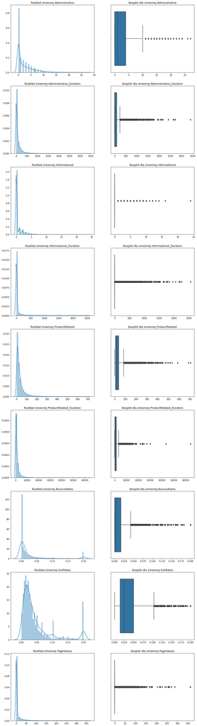

```python
var=list(data.columns[0:9])
fig, axes=plt.subplots(9, 2, figsize=(15, 60))
for i in range(0, len(var)):
    sns.distplot(data[var[i]], ax=axes[i, 0]).set(xlabel="", title='Rozkład zmiennej '+var[i])
    sns.boxplot(data[var[i]], ax=axes[i, 1]).set(xlabel='', title='Boxplot dla zmiennej '+var[i])
```

## Rozkłady zmiennych kategorycznych

### Revenue

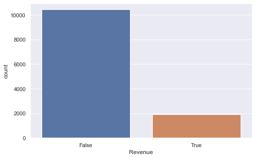

```python
sns.set(style="darkgrid")
plt.figure(figsize=(8,5))
sns.countplot(data.Revenue)
plt.show()
```

Obserwacje, dla których transakcja się odbyła stanowią mniejszość (15,5% wszystkich obserwacji).

### OperatingSystems, Browser, Region, TrafficType

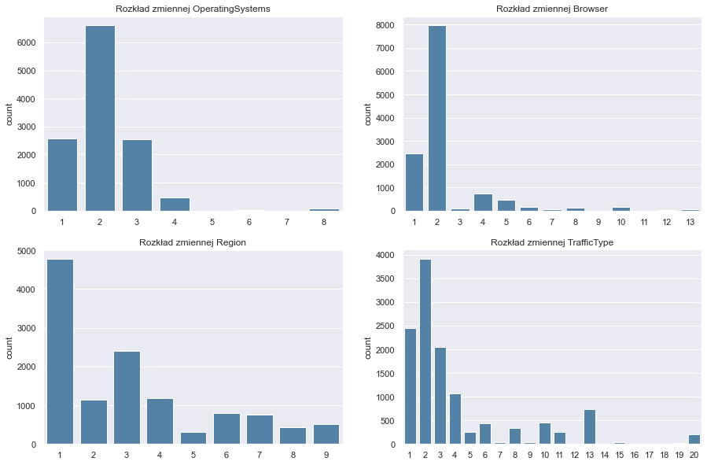

```python
var2=['OperatingSystems','Browser','Region','TrafficType']
fig, axes=plt.subplots(2, 2, figsize=(15, 10))
for i in range(0, len(var2)):
    sns.countplot(data[var2[i]], ax=axes[i//2, i%2], color='steelblue').set(xlabel="", title='Rozkład zmiennej '+var2[i])
```

- OperatingSystem: najwięcej obserwacji dla typów: 2,1,3
- Browser: zdecydowana przewaga 2, druga w kolejności - 1
- Region: najwięcej użytkowników z regionu 1 oraz 3
- TrafficType: najwięcej obserwacji dla 2,1,3

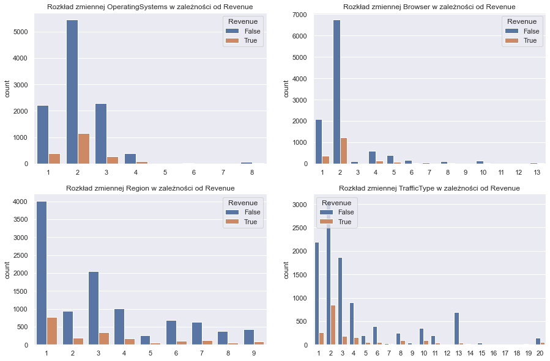

```python
fig, axes=plt.subplots(2, 2, figsize=(15, 10))
for i in range(0, len(var2)):
    sns.countplot(data[var2[i]], ax=axes[i//2, i%2], hue=data.Revenue).set(xlabel="",
                  title='Rozkład zmiennej '+var2[i]+' w zależności od Revenue')
```

### Month

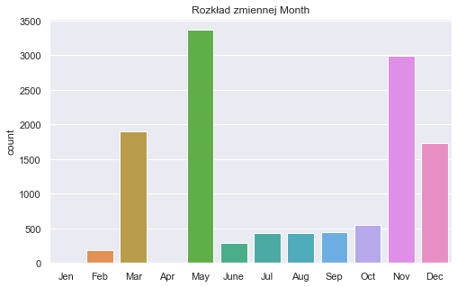

```python
plt.figure(figsize=(8,5))
sns.countplot(data.Month, order=['Jen','Feb','Mar','Apr','May','June','Jul','Aug','Sep','Oct','Nov','Dec']).set(xlabel="",
              title='Rozkład zmiennej Month')
plt.show()
```

- Zbiór nie zawiera żadnych rekordów dla stycznia oraz kwietnia
- Dominują zdecydowanie: maj, listopad, marzec oraz grudzień

Dotyczy to jednak wszystkich wizyt - zarówno tych, które skończyły się zakupem jak i nie. W podanych czterech miesiącach najczęściej uzytkownicy odwiedzali stronę. Sprawdźmy zatem w jakich miesiącach ich odwiedziny najczęściej kończyły się transakcją.

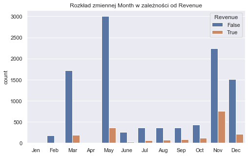

```python
plt.figure(figsize=(8,5))
sns.countplot(data.Month, order=['Jen','Feb','Mar','Apr','May','June','Jul','Aug','Sep','Oct','Nov','Dec'],
              hue=data.Revenue).set(xlabel="", title='Rozkład zmiennej Month w zależności od Revenue')
plt.show()
```

- Najczęściej zakupy dochodziły do finalizacji w listopadzie
- W maju jest widoczne zaintersowanie uzytkowników (liczba odwiedzających stronę), jednak na zakup decyduje się niewielka część z nich

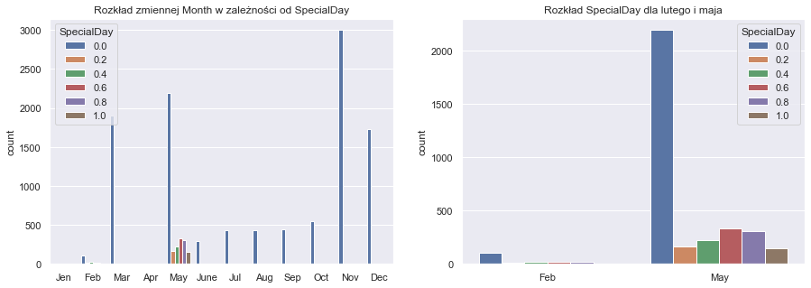

```python
fig, axes=plt.subplots(1, 2, figsize=(15, 5))
sns.countplot(data.Month, order=['Jen','Feb','Mar','Apr','May','June','Jul','Aug','Sep','Oct','Nov','Dec'],
              hue=data.SpecialDay, ax=axes[0]).set(xlabel="", title='Rozkład zmiennej Month w zależności od SpecialDay')
sns.countplot(data[data.Month=='Feb'].append(data[data.Month=='May']).Month, hue=data.SpecialDay,
              ax=axes[1]).set(xlabel="", title='Rozkład SpecialDay dla lutego i maja')
plt.show()
```

Wartość *SpecialDay* oznacza bliskość daty transakcji do szczególnych dni lub świąt (np. Dzień Matki). Im wyższa wartość tym danej dacie bliżej do bycia świętem, w szczególności:

- 0.0 - w okolicach tej daty nie ma żadnego święta
- 1.0 - ta data jest uznawana za święto

```python
(data[data['SpecialDay']>0]).Month.value_counts()
```

```
May    1172
Feb      79
Name: Month, dtype: int64
```

- Zaskakująco jedynie w lutym i maju obserwujemy jakiekolwiek zakupy związane ze zbliżającymi się świętami lub inną 'specjalną okazją'
- Zdecydowanie większość tych obserwacji przypada na maj

### Weekend

```
Proporcja dni weekendowych do roboczych:0.30310716550412176
```

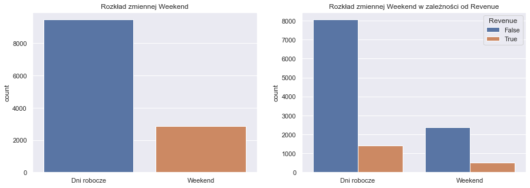

```python
fig, axes=plt.subplots(1, 2, figsize=(15, 5))
print('Proporcja dni weekendowych do roboczych:'+str(data.Weekend.value_counts()[1]/data.Weekend.value_counts()[0]))
sns.countplot(data.Weekend, ax=axes[0]).set(xlabel="", title='Rozkład zmiennej Weekend',
                                           xticklabels=['Dni robocze', 'Weekend'])
sns.countplot(data.Weekend, hue=data.Revenue,
              ax=axes[1]).set(xlabel="", title='Rozkład zmiennej Weekend w zależności od Revenue',
                             xticklabels=['Dni robocze', 'Weekend'])
plt.show()
```

Zaskakująco w weekendy użytkownicy rzadziej odwiedzają stronę (proporcja 0.3, normalnie 0.4).

### VisitorType

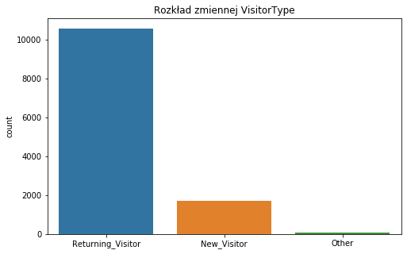

```python
plt.figure(figsize=(8,5))
sns.countplot(data.VisitorType).set(xlabel="", title='Rozkład zmiennej VisitorType')
data.VisitorType.value_counts()
plt.show()
```

Wyróżniamy trzy typy użytkowników:

- Returning_Visitor - powracający/stały klient
- New_Visitor - nowy klient
- Other - w opisie zbioru była informacja o dwóch, wspomnianych wyżej typach, nie wiadomo jak interpretować tę grupę. W dalszej części prac zostaine ona usunięta

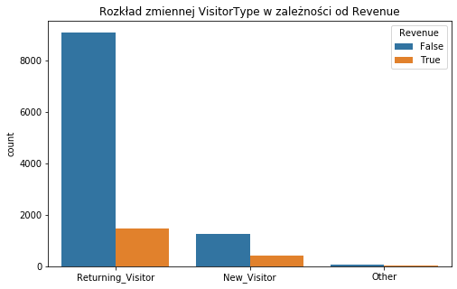

```python
plt.figure(figsize=(8,5))
sns.countplot(data.VisitorType, hue=data.Revenue).set(xlabel="",
              title='Rozkład zmiennej VisitorType w zależności od Revenue')
plt.show()
```

Nowi klienci są bardziej chętni do kupowania niż stali/powracający klienci.

## Korelacje zmiennych

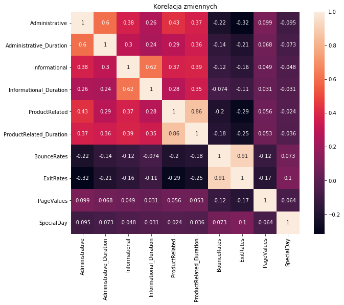

```python
Bouncecorr=data.corr()
plt.figure(figsize=(10,8))
sns.heatmap(Bouncecorr,
            xticklabels=Bouncecorr.columns,
            yticklabels=Bouncecorr.columns, annot=True).set_title("Korelacja zmiennych")
plt.show()
```

## Przygotowanie zbiotu danych

Na prosces przygotowania zbioru danych składało się:

- Usunięcie outlierów
- Zredukowanie liczby kategorii dla zmiennych *OperatingSystems, Browser, Region oraz TrafficType*
- One-hot encoding
- Standaryzacja zmiennych
- Redukcja wymiarów

### Usunięcie outlierów

Usunięte zostaną wiersze z odstającymi wartościami, wybranymi na podstawie wykresów rozkładów.

```python
data = data[data.ProductRelated_Duration < 20000]
data = data[data.Administrative_Duration < 3000]
data = data[data.PageValues < 350]
data = data[data.ProductRelated < 550]
```

### Zredukowanie liczby kategorii

Pojawiające się w zbiorze zmienne kategorycze mają wiele poziomów, z których część jest bardzo nieliczna. Zostaną one więc zagregowane do wspólnej kateorii *Other*.

```python
data.loc[~data.OperatingSystems.isin([1,2,3]), 'OperatingSystems'] = 'Other'
data.OperatingSystems.value_counts()
```

```
2        6591
1        2584
3        2555
Other     588
Name: OperatingSystems, dtype: int64
```

```python
data.loc[~data.Browser.isin([1,2,4,5]), 'Browser'] = 'Other'
data.Browser.value_counts()
```

```
2        7952
1        2461
4         735
Other     703
5         467
Name: Browser, dtype: int64
```

```python
data.loc[~data.Region.isin([1,2,3,4]), 'Region'] = 'Other'
data.Region.value_counts()
```

```
1        4772
Other    2828
3        2401
4        1181
2        1136
Name: Region, dtype: int64
```

```python
data.loc[~data.TrafficType.isin([1,2,3,4,13]), 'TrafficType'] = 'Other'
data.TrafficType.value_counts()
```

```
2        3908
1        2450
Other    2104
3        2051
4        1069
13        736
Name: TrafficType, dtype: int64
```

### One-hot encoding

Dla zmiennych kategorycznych stosujemy metodę One-hot encoding. Polega ona na tym, że dla każdej z kategorii kodowanej zmiennej tworzona jest nowa kolumna, która przyjmuje wartość 0, jeśli rekord nie jest w danej kategorii lub 1, jeśli jest.

```python
data_raw=data
data= pd.get_dummies(data)
data.columns
```

```
Index(['Administrative', 'Administrative_Duration', 'Informational',
       'Informational_Duration', 'ProductRelated', 'ProductRelated_Duration',
       'BounceRates', 'ExitRates', 'PageValues', 'SpecialDay', 'Month_Aug',
       'Month_Dec', 'Month_Feb', 'Month_Jul', 'Month_June', 'Month_Mar',
       'Month_May', 'Month_Nov', 'Month_Oct', 'Month_Sep',
       'OperatingSystems_1', 'OperatingSystems_2', 'OperatingSystems_3',
       'OperatingSystems_Other', 'Browser_1', 'Browser_2', 'Browser_4',
       'Browser_5', 'Browser_Other', 'Region_1', 'Region_2', 'Region_3',
       'Region_4', 'Region_Other', 'TrafficType_1', 'TrafficType_2',
       'TrafficType_3', 'TrafficType_4', 'TrafficType_13', 'TrafficType_Other',
       'VisitorType_New_Visitor', 'VisitorType_Other',
       'VisitorType_Returning_Visitor', 'Weekend_False', 'Weekend_True',
       'Revenue_False', 'Revenue_True'],
      dtype='object')
```

### Standaryzacja zmiennych

Dzięki kodowaniu wszystkie zmienne są już numeryczne, a zatem można przeprowadzić ich standaryzację.

```python
from sklearn.preprocessing import StandardScaler
scaler = StandardScaler()
scaler.fit(data)
data_scaled = pd.DataFrame(scaler.transform(data), columns=data.columns)
data_scaled.head()
```

|  | Administrative | Administrative_Duration | Informational | Informational_Duration | ProductRelated | ProductRelated_Duration | BounceRates | ExitRates | PageValues | SpecialDay | ... | TrafficType_4 | TrafficType_13 | TrafficType_Other | VisitorType_New_Visitor | VisitorType_Other | VisitorType_Returning_Visitor | Weekend_False | Weekend_True | Revenue_False | Revenue_True |
| --- | --- | --- | --- | --- | --- | --- | --- | --- | --- | --- | --- | --- | --- | --- | --- | --- | --- | --- | --- | --- | --- |
| 0 | -0.698597 | -0.471126 | -0.400816 | -0.248169 | -0.718701 | -0.694260 | 3.665300 | 3.227719 | -0.323803 | -0.308986 | ... | -0.308270 | -0.252085 | -0.453863 | -0.399176 | -0.082862 | 0.410585 | 0.550776 | -0.550776 | 0.427587 | -0.427587 |
| 1 | -0.698597 | -0.471126 | -0.400816 | -0.248169 | -0.695014 | -0.656323 | -0.457864 | 1.170555 | -0.323803 | -0.308986 | ... | -0.308270 | -0.252085 | -0.453863 | -0.399176 | -0.082862 | 0.410585 | 0.550776 | -0.550776 | 0.427587 | -0.427587 |
| 2 | -0.698597 | -0.471126 | -0.400816 | -0.248169 | -0.718701 | -0.694260 | 3.665300 | 3.227719 | -0.323803 | -0.308986 | ... | -0.308270 | -0.252085 | -0.453863 | -0.399176 | -0.082862 | 0.410585 | 0.550776 | -0.550776 | 0.427587 | -0.427587 |
| 3 | -0.698597 | -0.471126 | -0.400816 | -0.248169 | -0.695014 | -0.692679 | 0.572927 | 1.993421 | -0.323803 | -0.308986 | ... | 3.243905 | -0.252085 | -0.453863 | -0.399176 | -0.082862 | 0.410585 | 0.550776 | -0.550776 | 0.427587 | -0.427587 |
| 4 | -0.698597 | -0.471126 | -0.400816 | -0.248169 | -0.505517 | -0.322298 | -0.045547 | 0.141973 | -0.323803 | -0.308986 | ... | 3.243905 | -0.252085 | -0.453863 | -0.399176 | -0.082862 | 0.410585 | -1.815620 | 1.815620 | 0.427587 | -0.427587 |

5 rows × 47 columns

## Redukcja wymiarów

Nasz zbiór ma obecnie 47 kolumn. Aby trochę zmniejszyć liczbę wymiarów, najpierw usuwamy dwie zbędne kolumny (*Weekend_False, Revenue_False*), gdyż istnieją już takie same kolumny tylko z przciwnymi wartościami. Następnie przeprowadzimy PCA (Principal Component Analysis), czyli analizę składowych głównych.

```python
data_scaled=data_scaled.drop(columns=['Weekend_False', 'Revenue_False'])
```

Sprawdzimy też, jak sprawdzi się algorytm PCA na zmiennych naszego zbioru.

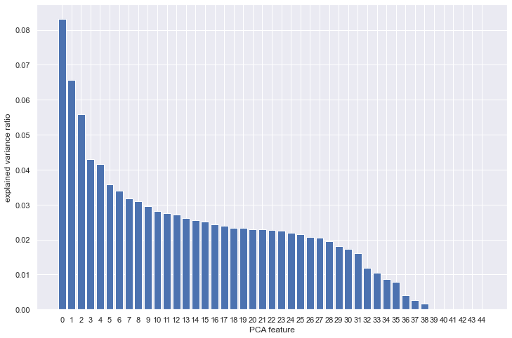

```python
from sklearn.decomposition import PCA

pca=PCA()
data_pca=pca.fit_transform(data_scaled)
features = range(pca.n_components_)
plt.figure(figsize=(12,8))
plt.bar(features, pca.explained_variance_ratio_)
plt.xlabel('PCA feature')
plt.ylabel('explained variance ratio')
plt.xticks(features)
plt.show()
```

Ponieważ powyżej 38 komponentu wyjaśniają one już bardzo niewielki ułamek procenta wariancji, dopasujemy do danych PCA o 38 komponentach i tymi danymi będziemy się posługiwać w dalszej analizie.

```python
pca38=PCA(n_components=38)
data_pca=pd.DataFrame(pca38.fit_transform(data_scaled))
```

# 3. Opis eksperymentu

Naszym celem jest znalezienie rodzajów klientów na podstwie zgromadzonych danych. Do tego celu użyjemy wszystkich dostępnych zmiennych w zborze danych uprzednio je przygotowywując (tak jak opisano powyżej). Dodatkowo rozważymy dwa zbiory danych - przed PCA (tylko przeskalowane) i po PCA. Na każdym z nich wypróbujemy 10 metod klasteryzacji wymienionych poniżej.

## Metody klasteryzacji

- Kmeans
- Agglomerative average linkage
- Agglomerative single linkage
- Agglomerative ward linkage
- Agglomerative complete linkage
- GMM covariance full
- GMM covariance tied
- GMM covariance diag
- GMM covariance spherical
- DBSCAN

## Metryki

Do porównania modeli posłużymy się trzema metrykami:

**1. The Silhouette Coefficient:**

Dla każdej obserwacji wyliczane są 2 wartości:

```
a: Średnia odległość od wszystkich punktów z tej samego klastra co obserwacja
b: Średnia odległość obserwacji od wszystkich punktów z kolejnego najbliższego klastra.
```

*Zakres wartości:*

```
-1 (dla niepoprawnej klasteryzacji)
1 (dla bardzo gęstych klastrów)
0 oznacza nakładające się klastry
```

**2. Davies-Bouldin Index:**

Oznacza średnie 'podobieństwo' między klastrami, gdzie miara podobieństwa porównuje odległość między klastrami z ich wielkością.

*Wartość:* im bliższa 0, tym podział lepszy

**3. Calinski-Harabasz Index:**

Oznacza stosunek pomiędzy sumą kwadratów odległości pomiędzy klastrami oraz sumą kwadratów odległości wewnątrz klastrów.

*Wartość:* im wyższa tym klastry gęstsze i lepiej oddzielone od siebie

Warto zauważyć, że według dokumentacji wszystkie powyższe metryki faworyzują wypukłe klastry ponad inne typy (np. oparte na gęstości, takie, jak zwraca DBSCAN i GMM).

# 4. Przeprowadzenie eksperymentu

Dla każdej metryki zostaną stworzone 3 tabele zawierające wyniki w każdej z 3 metryk - dla każdego modelu sprawdzimy liczbę klastrów od 2 do 9. Ponieważ DBSCAN nie przyjmuje liczby klastrów jako argumentu, a dobiera je automatycznie, zostanie on zapisany w osobnej tabeli, gdzie sprawdzimy jego działanie dla argumenty epsilon, dla wartości od 0.1 do 1.

```python
from sklearn.metrics import silhouette_score, davies_bouldin_score, calinski_harabaz_score
from functools import partial
from sklearn import cluster, mixture
from sklearn.cluster import KMeans, DBSCAN, AgglomerativeClustering
from sklearn.mixture import GaussianMixture
```

```python
cluster_num_seq = range(2, 10)

models = {
            'Kmeans': KMeans,
            'Agglomerative average linkage': partial(AgglomerativeClustering, linkage='average'),
            'Agglomerative single linkage': partial(AgglomerativeClustering, linkage='single'),
            'Agglomerative ward linkage': partial(AgglomerativeClustering, linkage='ward'),
            'Agglomerative complete linkage': partial(AgglomerativeClustering, linkage='complete'),
            'GMM covariance full': partial(GaussianMixture, covariance_type='full'),
            'GMM covariance tied': partial(GaussianMixture, covariance_type='tied'),
            'GMM covariance diag': partial(GaussianMixture, covariance_type='diag'),
            'GMM covariance spherical': partial(GaussianMixture, covariance_type='spherical')
         }

epsilons=np.arange(0.1, 1.1, 0.1)
```

## Data_scaled

Wytrenowanie modeli na przeskalowanych danych, bez PCA.

```python
sil_scaled = pd.DataFrame()
db_scaled = pd.DataFrame()
ch_scaled = pd.DataFrame()

for model_key in models:
    for k in cluster_num_seq:
        model=models[model_key]
        model_instance = model(k)
        labels = model_instance.fit_predict(data_scaled)
        sil_scaled.loc[model_key, k] = silhouette_score(data_scaled, labels)
        db_scaled.loc[model_key, k] = davies_bouldin_score(data_scaled, labels)
        ch_scaled.loc[model_key, k] = calinski_harabaz_score(data_scaled, labels)
```

```python
sil_scaled_dbscan = pd.DataFrame()
db_scaled_dbscan = pd.DataFrame()
ch_scaled_dbscan = pd.DataFrame()

for epsilon in epsilons:
        model_instance = DBSCAN(eps=epsilon)
        labels = model_instance.fit_predict(data_scaled)
        sil_scaled_dbscan.loc["DBSCAN", epsilon] = silhouette_score(data_scaled, labels)
        db_scaled_dbscan.loc["DBSCAN", epsilon] = davies_bouldin_score(data_scaled, labels)
        ch_scaled_dbscan.loc["DBSCAN", epsilon] = calinski_harabaz_score(data_scaled, labels)
```

### Wyniki Silhouette

```python
sil_scaled
```

|  | 2 | 3 | 4 | 5 | 6 | 7 | 8 | 9 |
| --- | --- | --- | --- | --- | --- | --- | --- | --- |
| Kmeans | 0.091129 | 0.090503 | 0.086144 | 0.086739 | 0.075874 | 0.071006 | 0.071784 | 0.071151 |
| Agglomerative average linkage | 0.525247 | 0.509058 | 0.434780 | 0.419892 | 0.409414 | 0.381361 | 0.367731 | 0.361471 |
| Agglomerative single linkage | 0.431582 | 0.419855 | 0.417975 | 0.417264 | 0.415191 | 0.415237 | 0.412709 | 0.412432 |
| Agglomerative ward linkage | 0.048444 | 0.051664 | 0.055304 | 0.058851 | 0.050016 | 0.043997 | 0.055695 | 0.066171 |
| Agglomerative complete linkage | 0.373563 | 0.355664 | 0.258499 | 0.252971 | 0.211822 | 0.114048 | 0.113618 | 0.113260 |
| GMM covariance full | 0.046048 | 0.029787 | 0.054884 | 0.064421 | 0.039275 | 0.031576 | 0.065043 | 0.065788 |
| GMM covariance tied | 0.082775 | 0.091444 | 0.097644 | 0.078315 | 0.060969 | 0.080346 | 0.084086 | 0.065052 |
| GMM covariance diag | 0.092786 | 0.039546 | 0.069294 | 0.031674 | 0.032195 | 0.061640 | 0.056600 | 0.065263 |
| GMM covariance spherical | 0.089855 | -0.012505 | 0.004175 | 0.042339 | 0.022182 | 0.029509 | 0.002212 | -0.001677 |

```python
sil_scaled_dbscan
```

|  | 0.1 | 0.2 | 0.3 | 0.4 | 0.5 | 0.6 | 0.7 | 0.8 | 0.9 | 1.0 |
| --- | --- | --- | --- | --- | --- | --- | --- | --- | --- | --- |
| DBSCAN | -0.087482 | -0.279349 | -0.307178 | -0.336659 | -0.35586 | -0.355025 | -0.341273 | -0.326251 | -0.31379 | -0.294644 |

### Wyniki Davies-Bouldin Score

```python
db_scaled
```

|  | 2 | 3 | 4 | 5 | 6 | 7 | 8 | 9 |
| --- | --- | --- | --- | --- | --- | --- | --- | --- |
| Kmeans | 3.168371 | 2.947764 | 2.872778 | 2.708672 | 2.961249 | 2.653190 | 2.860040 | 2.421831 |
| Agglomerative average linkage | 0.745945 | 0.617932 | 0.826805 | 0.841061 | 0.913413 | 1.100896 | 1.203688 | 1.040729 |
| Agglomerative single linkage | 0.915336 | 0.748270 | 0.686798 | 0.621227 | 0.576259 | 0.585273 | 0.562274 | 0.542813 |
| Agglomerative ward linkage | 4.036125 | 4.081142 | 3.224360 | 3.062499 | 2.871754 | 3.131271 | 2.766245 | 2.576381 |
| Agglomerative complete linkage | 1.789550 | 1.588618 | 1.249371 | 1.320418 | 1.460504 | 2.039324 | 2.048617 | 1.982376 |
| GMM covariance full | 4.837084 | 4.077905 | 3.473143 | 4.034066 | 3.640122 | 3.364144 | 3.875371 | 3.301847 |
| GMM covariance tied | 5.105397 | 2.410397 | 2.568161 | 3.021502 | 2.830879 | 2.719940 | 2.952676 | 2.656642 |
| GMM covariance diag | 3.151673 | 3.792900 | 3.839338 | 3.560037 | 3.092738 | 2.993483 | 3.641702 | 2.829693 |
| GMM covariance spherical | 2.636786 | 2.696209 | 4.540302 | 4.378997 | 3.525005 | 3.442713 | 3.475232 | 3.222313 |

```python
db_scaled_dbscan
```

|  | 0.1 | 0.2 | 0.3 | 0.4 | 0.5 | 0.6 | 0.7 | 0.8 | 0.9 | 1.0 |
| --- | --- | --- | --- | --- | --- | --- | --- | --- | --- | --- |
| DBSCAN | 0.907133 | 1.282906 | 1.300271 | 1.357934 | 1.394969 | 1.421104 | 1.417036 | 1.419126 | 1.430098 | 1.425065 |

### Wyniki Calinski-Harabasz Score

```python
ch_scaled
```

|  | 2 | 3 | 4 | 5 | 6 | 7 | 8 | 9 |
| --- | --- | --- | --- | --- | --- | --- | --- | --- |
| Kmeans | 772.512622 | 687.152982 | 673.416171 | 635.036418 | 591.353221 | 568.438620 | 534.928501 | 526.995423 |
| Agglomerative average linkage | 26.422254 | 16.781832 | 26.047695 | 105.263973 | 85.318046 | 88.209797 | 76.943607 | 67.627043 |
| Agglomerative single linkage | 338.593067 | 172.104285 | 115.694936 | 88.642847 | 72.477085 | 62.961251 | 54.823933 | 48.777124 |
| Agglomerative ward linkage | 437.161285 | 407.038710 | 396.922583 | 397.226537 | 402.213519 | 402.944615 | 405.980598 | 409.678390 |
| Agglomerative complete linkage | 246.965438 | 178.191514 | 181.846615 | 184.917523 | 169.918620 | 189.816082 | 166.660833 | 147.722583 |
| GMM covariance full | 494.576566 | 560.117451 | 594.833833 | 331.621686 | 330.066438 | 363.335395 | 318.952427 | 399.425068 |
| GMM covariance tied | 342.945695 | 492.517491 | 540.125720 | 517.951529 | 513.552721 | 461.557987 | 432.945363 | 458.375928 |
| GMM covariance diag | 771.281897 | 558.918649 | 489.448325 | 410.660746 | 420.671663 | 395.090226 | 369.240811 | 400.394419 |
| GMM covariance spherical | 231.089353 | 540.082350 | 428.117804 | 338.272974 | 420.222566 | 397.032784 | 373.178689 | 339.784178 |

```python
ch_scaled_dbscan
```

|  | 0.1 | 0.2 | 0.3 | 0.4 | 0.5 | 0.6 | 0.7 | 0.8 | 0.9 | 1.0 |
| --- | --- | --- | --- | --- | --- | --- | --- | --- | --- | --- |
| DBSCAN | 11.037596 | 6.561288 | 6.797916 | 7.164039 | 6.069196 | 5.843531 | 6.721481 | 6.804064 | 6.897287 | 6.629592 |

## Data_pca

W tej części eksperymentu przeprowadzimy analogiczne modelowanie dla danych po przeprowadzeniu PCA.

```python
sil_pca = pd.DataFrame()
db_pca = pd.DataFrame()
ch_pca = pd.DataFrame()

for model_key in models:
    for k in cluster_num_seq:
        model=models[model_key]
        model_instance = model(k)
        labels = model_instance.fit_predict(data_pca)
        sil_pca.loc[model_key, k] = silhouette_score(data_pca, labels)
        db_pca.loc[model_key, k] = davies_bouldin_score(data_pca, labels)
        ch_pca.loc[model_key, k] = calinski_harabaz_score(data_pca, labels)
```

```python
sil_pca_dbscan = pd.DataFrame()
db_pca_dbscan = pd.DataFrame()
ch_pca_dbscan = pd.DataFrame()

for epsilon in epsilons:
        model_instance = DBSCAN(eps=epsilon)
        labels = model_instance.fit_predict(data_pca)
        sil_pca_dbscan.loc["DBSCAN", epsilon] = silhouette_score(data_pca, labels)
        db_pca_dbscan.loc["DBSCAN", epsilon] = davies_bouldin_score(data_pca, labels)
        ch_pca_dbscan.loc["DBSCAN", epsilon] = calinski_harabaz_score(data_pca, labels)
```

### Wyniki Silhouette score

```python
sil_pca
```

|  | 2 | 3 | 4 | 5 | 6 | 7 | 8 | 9 |
| --- | --- | --- | --- | --- | --- | --- | --- | --- |
| Kmeans | 0.091262 | 0.087366 | 0.086295 | 0.086809 | 0.060379 | 0.066787 | 0.073797 | 0.106323 |
| Agglomerative average linkage | 0.514263 | 0.496523 | 0.426024 | 0.409022 | 0.406037 | 0.402042 | 0.400852 | 0.324245 |
| Agglomerative single linkage | 0.431889 | 0.420080 | 0.418204 | 0.417498 | 0.415429 | 0.415476 | 0.412964 | 0.412689 |
| Agglomerative ward linkage | 0.052498 | 0.057619 | 0.060209 | 0.048707 | 0.056199 | 0.051630 | 0.063314 | 0.073809 |
| Agglomerative complete linkage | 0.261132 | 0.242898 | 0.249351 | 0.206803 | 0.206282 | 0.144475 | 0.144189 | 0.143333 |
| GMM covariance full | 0.045965 | 0.030237 | 0.045058 | 0.049581 | 0.039392 | 0.055467 | 0.063464 | 0.058599 |
| GMM covariance tied | 0.083073 | 0.083276 | 0.087072 | 0.090027 | 0.070548 | 0.085106 | 0.085761 | 0.087948 |
| GMM covariance diag | 0.065374 | 0.038329 | 0.021545 | 0.012344 | -0.012607 | 0.010394 | 0.032989 | 0.012876 |
| GMM covariance spherical | 0.064950 | 0.036309 | -0.024660 | 0.027304 | 0.026249 | 0.019367 | 0.009136 | 0.019550 |

```python
sil_pca_dbscan
```

|  | 0.1 | 0.2 | 0.3 | 0.4 | 0.5 | 0.6 | 0.7 | 0.8 | 0.9 | 1.0 |
| --- | --- | --- | --- | --- | --- | --- | --- | --- | --- | --- |
| DBSCAN | -0.224115 | -0.278042 | -0.335083 | -0.349882 | -0.356609 | -0.345888 | -0.335398 | -0.313822 | -0.302077 | -0.28394 |

### Wyniki Davies-Bouldin Score

```python
db_pca
```

|  | 2 | 3 | 4 | 5 | 6 | 7 | 8 | 9 |
| --- | --- | --- | --- | --- | --- | --- | --- | --- |
| Kmeans | 3.165324 | 2.943897 | 2.869530 | 2.713818 | 2.802237 | 2.886488 | 2.592222 | 2.499225 |
| Agglomerative average linkage | 0.361956 | 0.842274 | 0.858265 | 0.941669 | 0.964203 | 0.898158 | 0.847243 | 1.048570 |
| Agglomerative single linkage | 0.913965 | 0.747343 | 0.685823 | 0.620380 | 0.575500 | 0.584666 | 0.561698 | 0.542269 |
| Agglomerative ward linkage | 3.908362 | 3.870557 | 3.514223 | 3.194683 | 2.767564 | 3.089784 | 2.689575 | 2.506219 |
| Agglomerative complete linkage | 2.527705 | 2.214353 | 1.893109 | 1.542000 | 1.481457 | 2.038513 | 1.965583 | 1.903057 |
| GMM covariance full | 4.829829 | 4.124526 | 3.547066 | 3.296763 | 3.211124 | 2.680201 | 4.019583 | 2.999618 |
| GMM covariance tied | 3.640423 | 2.768966 | 2.454795 | 2.590406 | 2.306085 | 2.800481 | 2.895576 | 2.627716 |
| GMM covariance diag | 5.791822 | 5.487711 | 5.246327 | 4.656318 | 3.948679 | 3.570636 | 3.519011 | 3.690233 |
| GMM covariance spherical | 2.922099 | 5.218616 | 4.530633 | 3.851343 | 3.230539 | 3.638765 | 3.330664 | 3.240396 |

```python
db_pca_dbscan
```

|  | 0.1 | 0.2 | 0.3 | 0.4 | 0.5 | 0.6 | 0.7 | 0.8 | 0.9 | 1.0 |
| --- | --- | --- | --- | --- | --- | --- | --- | --- | --- | --- |
| DBSCAN | 1.086063 | 1.27024 | 1.342437 | 1.374709 | 1.389468 | 1.402322 | 1.394776 | 1.40516 | 1.409401 | 1.412776 |

### Wyniki Calinski-Harabasz Score

```python
ch_pca
```

|  | 2 | 3 | 4 | 5 | 6 | 7 | 8 | 9 |
| --- | --- | --- | --- | --- | --- | --- | --- | --- |
| Kmeans | 773.868703 | 688.413359 | 674.685060 | 636.133934 | 600.719240 | 555.860143 | 539.822570 | 525.193355 |
| Agglomerative average linkage | 7.124065 | 25.781553 | 131.176266 | 113.900958 | 92.688274 | 77.817227 | 67.233536 | 74.333384 |
| Agglomerative single linkage | 339.167970 | 172.391778 | 115.888263 | 88.791057 | 72.598252 | 63.066217 | 54.915309 | 48.858150 |
| Agglomerative ward linkage | 464.997347 | 437.788103 | 421.275445 | 417.429586 | 419.794212 | 420.556695 | 421.990264 | 424.600307 |
| Agglomerative complete linkage | 215.251474 | 156.188412 | 222.889593 | 193.035401 | 170.231737 | 177.316677 | 153.344518 | 135.975440 |
| GMM covariance full | 495.820442 | 601.867327 | 592.454544 | 518.834221 | 452.298807 | 476.791109 | 275.367402 | 406.467879 |
| GMM covariance tied | 315.581451 | 529.643239 | 471.324766 | 514.114797 | 483.394646 | 441.036103 | 436.974824 | 474.140910 |
| GMM covariance diag | 344.036433 | 269.752864 | 255.833101 | 265.808423 | 369.788258 | 334.305347 | 354.314212 | 290.492514 |
| GMM covariance spherical | 588.387247 | 405.382066 | 423.907577 | 474.505974 | 408.909839 | 373.329664 | 368.829494 | 406.748866 |

```python
ch_pca_dbscan
```

|  | 0.1 | 0.2 | 0.3 | 0.4 | 0.5 | 0.6 | 0.7 | 0.8 | 0.9 | 1.0 |
| --- | --- | --- | --- | --- | --- | --- | --- | --- | --- | --- |
| DBSCAN | 9.045634 | 7.261581 | 6.872387 | 6.14112 | 5.684358 | 5.756872 | 6.381566 | 6.873809 | 6.744585 | 6.810174 |

# 5. Ocena wyników

Po przetestowaniu modeli na "surowych" danych ustandaryzowanych oraz po zastosowaniu PCA okazało się, że nie redukcja wymiarów nie przyniosła znacznej poprawy wyników modeli. Mimo to, skupimy się na tych drugich wynikach, chociażby ze względu na to, że mają one nieznacznie mniejszy wymiar.

Dwie z rozważanych metryk (Silhouette oraz Davies-Bouldin Score) wskazały ten sam algorytm jako najlepszy, w odróżnieniu od Calinski-Harabasz Score.

- **Silhouette Score** oraz **Davies-Bouldin Score** - *Agglomerative average linkage, n_clusters = 2*
- **Calinski-Harabasz Score** - *KMeans, n_clusters = 2*

```python
def plot_models(data):
    plt.figure(figsize=(14,8))
    for rowname in data.index:
        plt.plot(cluster_num_seq, data.loc[rowname], label=rowname)
    plt.grid(alpha=0.4)
    plt.legend(loc=1)
    plt.title('Kmeans, Agglometative & GMM')
    plt.show()
```

```python
def plot_dbscan(data):
    plt.figure(figsize=(14,8))
    plt.plot(epsilons,data.loc['DBSCAN'])
    plt.title('DBSCAN')
    plt.xticks(epsilons)
    plt.grid(alpha=0.4)
    plt.show()
```

```python
from sklearn.manifold import TSNE
from sklearn.datasets import load_digits
from sklearn.preprocessing import scale

random_state = 1500100900
digits_proj = TSNE(random_state=random_state).fit_transform(data_pca)
```

```python
def plot_scatter(x, colors):
    palette = np.array(sns.color_palette("hls", 10))

    f = plt.figure(figsize=(8, 8))
    ax = plt.subplot(aspect='equal')
    sc = ax.scatter(x[:,0], x[:,1], lw=0, s=40,
                    c=palette[colors.astype(np.int)])
    plt.xlim(-25, 25)
    plt.ylim(-25, 25)
    ax.axis('off')
    ax.axis('tight')

    # add labels
    txts = []
    for i in range(10):
        # Position of each label.
        xtext, ytext = np.median(x[colors == i, :], axis=0)
        txt = ax.text(xtext, ytext, str(i), fontsize=24)
        txts.append(txt)

    return f, ax, sc, txts
```

### Silhouette score

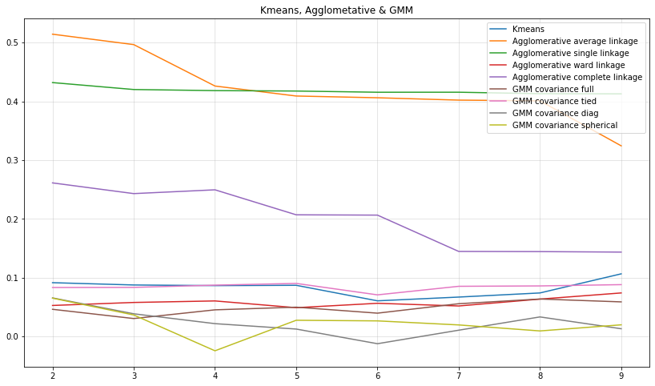

```python
plot_models(sil_pca)
```

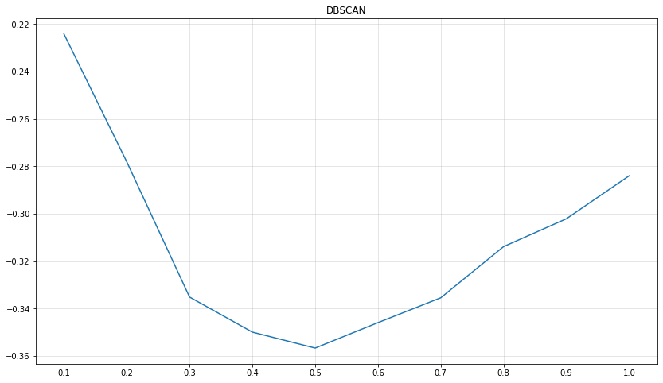

```python
plot_dbscan(sil_pca_dbscan)
```

Z powyższych wykresów wynika, że pod względem *Silhouette score* najlepszy okazał się model AgglomerativeClustering z parametrem *linkage='average'*, dla liczby klastrów równej 2. Wizualizacja za pomocą tSNE jednak szybko weryfikuje, że przydzielił on prawie wszystkie obserwacje do jednej kategorii.

[output not shown]

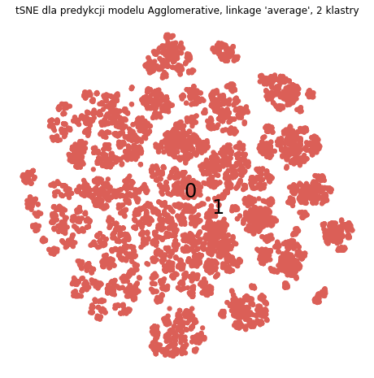

```python
model = AgglomerativeClustering(2, linkage='average')
labels = model.fit_predict(data_pca)
plot_scatter(digits_proj, labels)
plt.title("tSNE dla predykcji modelu Agglomerative, linkage 'average', 2 klastry")
plt.show()
```

### Davies-Bouldin Score

Index Daviesa-Bouldina sugeruje coś wprost przeciwnego do Silhouette - ocena większości modeli poprawia się wraz z wzrostem liczby klastrów. Jednakże, te same dwa modele: Agglomerative average i single linkage, uzyskują najlepsze wyniki.

[figure not shown]

```python
plot_models(db_pca)
```

DBSCAN dkla małych epsilonów radzi sobie nieźle, ale średnio plasuje się na 3 miejscu za wspomnianymi modelami.

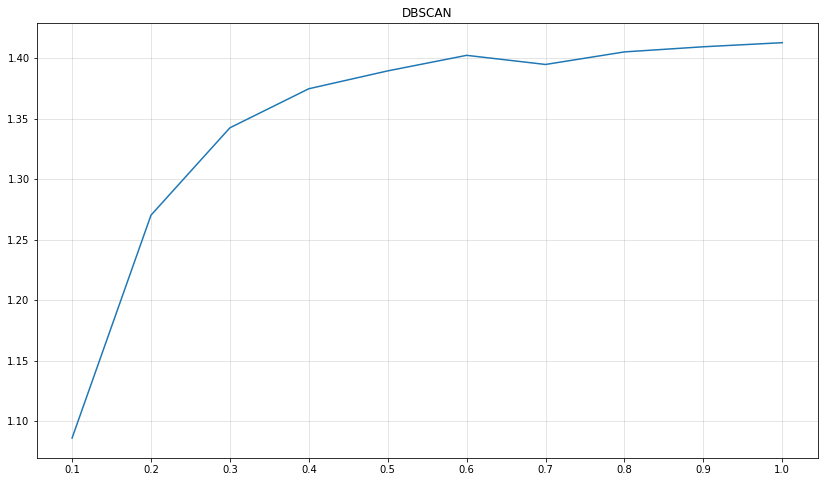

```python
plot_dbscan(db_pca_dbscan)
```

Z powyższych wykresów wynika, że pod względem *Davies-Bouldin score* również najlepszy okazał się model AgglomerativeClustering z parametrem *linkage='average'* i dla 2 klastrów (tak jak przy Silhouette score). Dla większych liczb klastrów jednak model z parametrem *'single'* osiągał od niego zawsze lepsze wyniki. Najniższą wartość metryki osiąga on dla 9 klastrów. Sprawdźmy więc, czy przypadkiem nie radzi sobie z klastrowaniem lepiej.

```
posx and posy should be finite values
posx and posy should be finite values
```

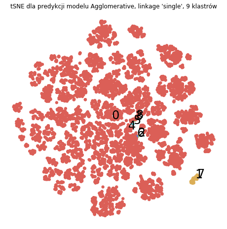

```python
model = AgglomerativeClustering(9, linkage='single')
labels = model.fit_predict(data_pca)
plot_scatter(digits_proj, labels)
plt.title("tSNE dla predykcji modelu Agglomerative, linkage 'single', 9 klastrów")
plt.show()
```

### Calinski-Harabasz Score

[figure not shown]

```python
plot_models(ch_pca)
```

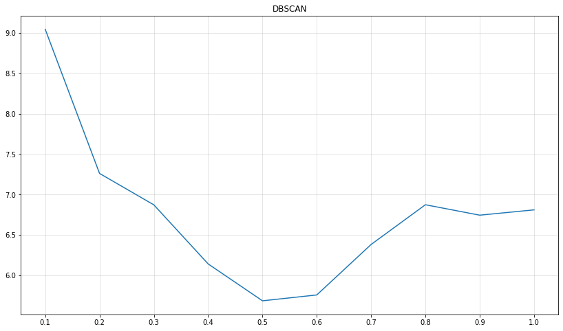

```python
plot_dbscan(ch_pca_dbscan)
```

Z powyższych wykresów wynika, że pod względem *Calinski-Harabasz score* najlepszy okazał się model KMeans dla liczby klastrów równej 2.

[output not shown]

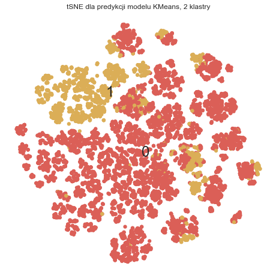

```python
model = KMeans(2)
labels = model.fit_predict(data_pca)
plot_scatter(digits_proj, labels)
plt.title("tSNE dla predykcji modelu KMeans, 2 klastry")
plt.show()
```

Jest to pierwszy algorytm, dla którego klastry są w miarę równej wielkości (a przynajmniej żaden z nich nie jest pojedynczą obserwacją)

```python
np.mean(labels)
```

```
0.7803214807598636
```

```python
data_kmeans=data
data_kmeans['labels']=labels
data_kmeans.groupby('labels').apply(lambda x: np.mean(x))
```

[output not shown]

Jedyna znacząca różnica widoczna jest w zmiennych Infromational Duration, ProductRelated oraz ProductRelated Duration.

# 6. Wnioski

Wszystkie zastosowane metryki sugerują, że dla tego zbioru najnaturalniejszym wyborem jest podział na dwa klastry. Grupy te nie są jednak dobrze wyodrębione, przez co wyniki żadnego z przebadanych modeli nie są satysfakcjonujące. Najlepszym w naszej opinii okazał się algorytm KMeans, który otrzymał najwyższy wynik według indeksu Calinskiego-Harabasza i w odróżnieniu od modeli, które uzyskały wysokie wyniki według innych metryk zwracał sensowny podział zbioru. Podział ten nie pozwala jednak wyciągnąć zbyt wielu wniosków na temat tego, co odróżnia od siebie wskazane grupy nabywców.

Otrzymane wyniki mogą sugerować źle dobrane cechy zbioru, co bardzo utrudnia lub nawet uniemożliwia otrzymanie klasteryzacji, z której możnaby wyciągnąć wnioski na temat typów użytkowników, którzy robią zakupy internetowe.

# 7. Bibliografia

1. https://archive.ics.uci.edu/ml/datasets/Online+Shoppers+Purchasing+Intention+Dataset
2. https://support.google.com/analytics/answer/2525491?hl=en&ref_topic=6156780
3. https://scikit-learn.org/stable/modules/clustering.html#silhouette-coefficient
4. https://scikit-learn.org/stable/modules/clustering.html#davies-bouldin-index
5. https://scikit-learn.org/stable/modules/clustering.html#calinski-harabasz-index

# 8. Oświadczenie

Oświadczamy, że niniejsza praca stanowiąca podstawę do uznania osiągnięcia efektów uczenia się z przedmiotu Wstęp do uczenia maszynowego została wykonana przez nas samodzielnie.

*Martyna Majchrzak (298826), Agata Makarewicz (298827), Renata Rólkiewicz (298840)*